# CS 422: Section 04

### d)

Multi regression variable

`r`r set.seed(1122) index <- sample(1:nrow(mpgI.df), 0.8*dim(mpgI.df)[1]) train <- mpgI.df[index, ] test <- mpgI.df[-index, ]

#### i.

car.name is not a reasonble option because it is a factor attribute with 305 different levels. The data set is of 392 objects, it makes no sense trying to classify the 392 objects in 305 diffentent levels. The model will predict much worse.

#### ii.

`r`r linearModMulti <- lm( formula = mpg ~ cylinders + displacement + horsepower + weight + acceleration + model.year + origin, data=train) summary(linearModMulti)

```
Call:
lm(formula = mpg ~ cylinders + displacement + horsepower + weight +
    acceleration + model.year + origin, data = train)

Residuals:
    Min      1Q  Median      3Q     Max
-7.9695 -1.9595 -0.0051  1.8549 12.0380

Coefficients:
               Estimate Std. Error t value Pr(>|t|)
(Intercept)  -2.265e+01  4.739e+00  -4.779 2.74e-06 ***
cylinders    -2.277e-01  3.599e-01  -0.633   0.5274
displacement  1.912e-02  7.617e-03   2.511   0.0126 *
horsepower    1.543e-02  7.680e-03   2.009   0.0454 *
weight       -6.947e-03  6.064e-04 -11.457  < 2e-16 ***
acceleration  1.555e-01  8.095e-02   1.921   0.0557 .
model.year    7.740e-01  5.481e-02  14.121  < 2e-16 ***
origin        1.513e+00  2.957e-01   5.115 5.54e-07 ***
---
Signif. codes:  0 ‘***’ 0.001 ‘**’ 0.01 ‘*’ 0.05 ‘.’ 0.1 ‘ ’ 1

Residual standard error: 3.188 on 305 degrees of freedom
Multiple R-squared:  0.8389,    Adjusted R-squared:  0.8352
F-statistic: 226.8 on 7 and 305 DF,  p-value: < 2.2e-16
```

We get an adjusted R^2= 0.8352, better (closser to one) than in b) using only one attribute. The RSE in this case it is 3.188, which also is smaller/better than in b).

`r`r RMSE <- sqrt(mean((train$mpg-linearModMulti$fit)^2)) RMSE

```
[1] 3.147463
```

### e)

#### i.

From d), the summary shows the attributes that most contribute with ***. Those are: weight, model.year and origin

`r`r linearModMultiC <- lm( formula = mpg ~ weight + model.year + origin, data=train)

#### ii.

`r`r summary(linearModMultiC)

```
Call:
lm(formula = mpg ~ weight + model.year + origin, data = train)

Residuals:
    Min      1Q  Median      3Q     Max
-7.9761 -2.1344 -0.0235  1.6861 12.5728

Coefficients:
              Estimate Std. Error t value Pr(>|t|)
(Intercept) -1.792e+01  4.460e+00  -4.019 7.35e-05 ***
weight      -5.826e-03  2.687e-04 -21.680  < 2e-16 ***
model.year   7.482e-01  5.403e-02  13.848  < 2e-16 ***
origin       1.251e+00  2.867e-01   4.364 1.74e-05 ***
---
Signif. codes:  0 ‘***’ 0.001 ‘**’ 0.01 ‘*’ 0.05 ‘.’ 0.1 ‘ ’ 1

Residual standard error: 3.24 on 309 degrees of freedom
Multiple R-squared:  0.8315,    Adjusted R-squared:  0.8298
F-statistic: 508.2 on 3 and 309 DF,  p-value: < 2.2e-16
```

We get an adjusted R^2= 0.8298, smaller than the previus d). The RSE in this case it is 3.24, which is greater/worse than in d).

`r`r RMSE <- sqrt(mean((train$mpg-linearModMultiC$fit)^2)) RMSE

```
[1] 3.218801
```

This results are normal. They are a bit worse than in d), however the results are really close. Therefore, is more computational-efficient to use the attributes that most contribute, seeing these results. ### f) Plot and comment the residuals of the model of (e)(i)

`r`r plot(linearModMultiC,1) abline(0,0)

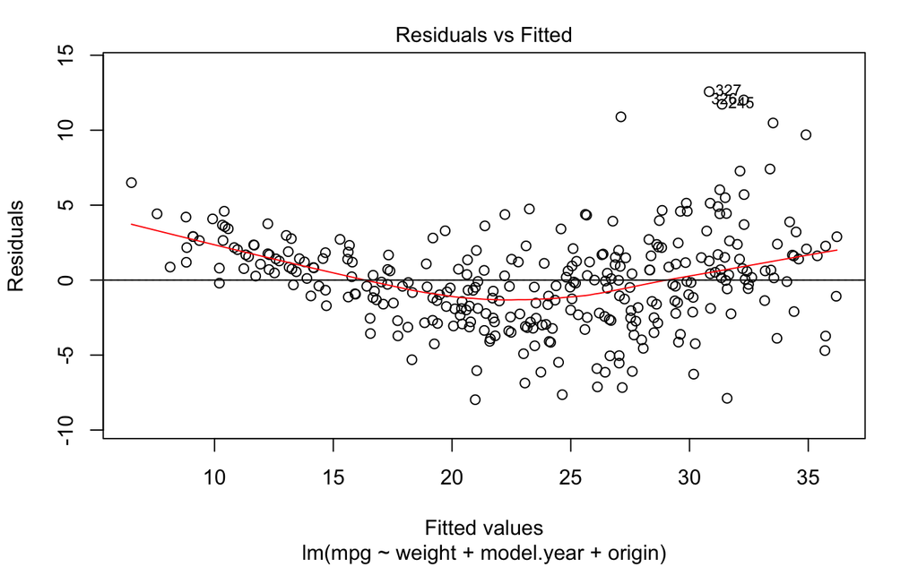

### g)

Plot a histogram of the residuals of the model of (e)(i)

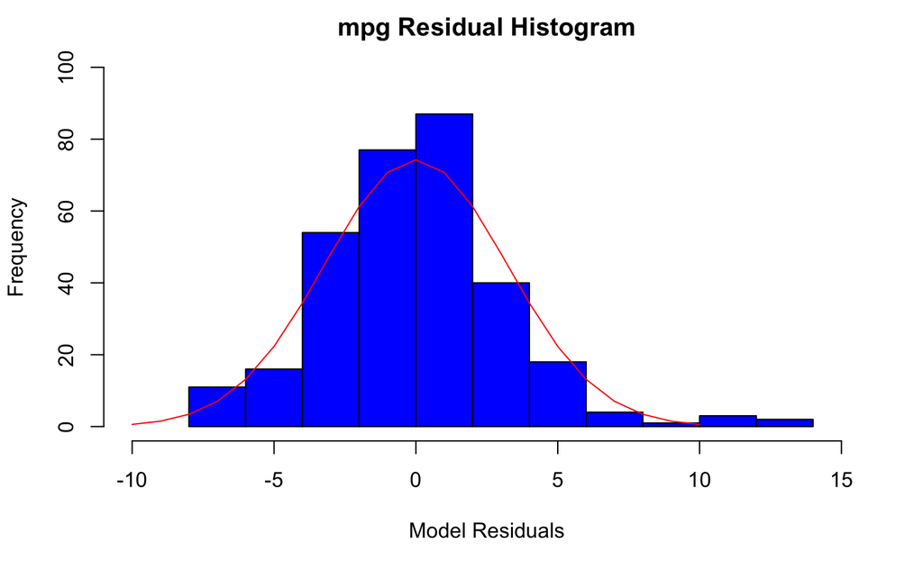

Yes, the residuals are close to a Gaussian distribution.

### h)

Prediction of the model

`r`r prediction<-predict(linearModMultiC, newdata=test) prediction<-data.frame(prediction) prediction$actual<-test$mpg prediction r difference<-prediction[1]-prediction[2] difference

|  | prediction | actual |
| --- | --- | --- |
| 4 | 15.69714 | 16.0 |
| 10 | 13.26764 | 15.0 |
| 11 | 14.93974 | 15.0 |
| 17 | 19.53656 | 18.0 |
| 20 | 26.25854 | 26.0 |
| 23 | 23.11243 | 25.0 |
| 24 | 23.93391 | 26.0 |
| 28 | 10.16814 | 11.0 |
| 32 | 25.96829 | 25.0 |
| 34 | 21.10039 | 19.0 |

[output cut: 69 more lines]

|  | prediction |
| --- | --- |
| 4 | -0.30286275 |
| 10 | -1.73236023 |
| 11 | -0.06026005 |
| 17 | 1.53655892 |
| 20 | 0.25854125 |
| 23 | -1.88757059 |
| 24 | -2.06608583 |
| 28 | -0.83186301 |
| 32 | 0.96828538 |
| 34 | 2.10038856 |

[output cut: 69 more lines]

If we look at the diference between both values, we can see that none of the points are exact, but they are close. If we consider the error to be 0:

`r`r sum(abs(difference)<0)

```
[1] 0
```

We see that 0 values out of 79 that fit the model with an error of 0.

### i)

`r`r n <- dim(test)[1] p <- 3

#### 1. RSS (Residual Sum of Errors)

`r`r RSS<-sum(difference^2) RSS

```
[1] 1115.528
```

#### 2. TSS (Total Sum of Errors)

`r`r ymean<-mean(prediction[,2]) TSS<-sum((prediction[,2]-ymean)^2) TSS

```
[1] 4571.97
```

#### 3. The F-statistic

`r`r F<-((TSS-RSS)/p)/(RSS/(n-p-1)) F

```
[1] 77.46201
```

#### 4. The RSE (Residual Standard Error)

`r`r RSE<-sqrt(1/(n-p-1)*RSS) RSE

```
[1] 3.856645
```

#### The RMSE (Residual Standard Error)

`r`r RMSE <- sqrt(mean((prediction[,2]-prediction[,1])^2)) RMSE

```
[1] 3.75774
```

From these results we can infer that the model performs quite worse than in the previous cases. For intance, the resulting RSE this time is equal to 3.856, which is greater than 3.24 from e). Also, the F value is smaller than in e). Eventhough the performance is a bit worse than before, the results are really close to their estimation.